# Activity 11: Linear Regression

Jerome Poblete

2026-07-06

## A. Simple linear regression

### 1. In RStudio, create an R Markdown file. Name it “Your Surname_linear_reg.rmd.”

You’re looking at it right now!

### 2. Read in the species data.

Make sure to remove unnecessary rows with NAs.

```r
library(tidyverse) # install.packages("tidyverse")

df_herp <- utils::read.csv("../data/herpetozoa-033-095-s001.csv")
df_herp <- df_herp[df_herp |> complete.cases(), ]
```

### 3. Read in the elevation data.

The file is given by `ph_strm_geo.tif`.

```r
library(terra) ## install.packages("terra")

sr_dem <- terra::rast("../data/ph_strm_geo.tif")
```

### 4. From the species data, subset the longitude and latitude coordinates.

Then convert the coordinates to a spatial vector (`SpatVector`). Use the “vect” function from the “terra” package.

```r
sv_coords <- terra::vect(df_herp, geom=c("Long", "Lat"))
```

### 5. Using the converted coordinates, extract elevation data for each point.

Use the “extract” function in the “terra” package. The extracted data will have two columns: “ID” and “Band_1.” The “Band_1” column contains the elevation.

```r
sv_dem_elev <- terra::extract(sr_dem, sv_coords)
```

### 6. Subset the species data to retain only the species richness column (SPPTotal).

Then combine this column with the extracted elevation. Rename “Band_1” to “elevation.”

```r
## Don't use `c` as that will just return a heterogenous vector, i.e. `vector(matrix, vector)
x     <- sv_dem_elev$Band_1
y     <- df_herp[, "SPPTotal"]
df_xy <- data.frame(x, y)

## Make plot axes names clearer.
colnames(df_xy) <- c("Elevation", "Species total")
```

### 7. Now, perform simple linear regression using the code from the pre-lab lecture.

Also include a plot. What can you infer about the relationship between species and elevation?

```r
## Regression Equation
##  y = a + b*x
##
## where
##  x: independent variable
##  y: dependent variable
##  a: intercept
##  b: slope
##
## Intercept
##  a = ybar - b*xbar
##
## where
##  xbar: mean(x)
##  ybar:  mean(y)
##
## Slope
##  b = sum(xdev * ydev) / sum(xdev^2)
##
## where
##  xdev: absolute devor of x = (x - xbar)
##  ydev: absolute devor of y = (y - ybar)

xbar <- mean(x)
xdev <- x - xbar

ybar <- mean(y)
ydev <- y - ybar
```

Our regression equation terms are given by the above equations.

```r
b <- sum(xdev * ydev) / sum(xdev^2)
b
```

```
## [1] -0.00372332
```

```r
a <- ybar - b*xbar
a
```

```
## [1] 4.175663
```

```r
## Write out the equation.
cat("Regression Equation: y =", round(a, 3), "+", round(b, 3), "x\n")
```

```
## Regression Equation: y = 4.176 + -0.004 x
```

```r
## Calculate predicted species count.
yhat <- a + b*x

## Calculate R-squared.
## Sum of Squared Errors (SSE)
SSE <- sum((y - yhat)^2)

## Total Sum of Squares (SST)
SST <- sum(ydev^2)

## Coefficient of Determination
R2 <- 1 - (SSE / SST)
R2
```

```
## [1] 0.1916095
```

#### i. Base R Plot

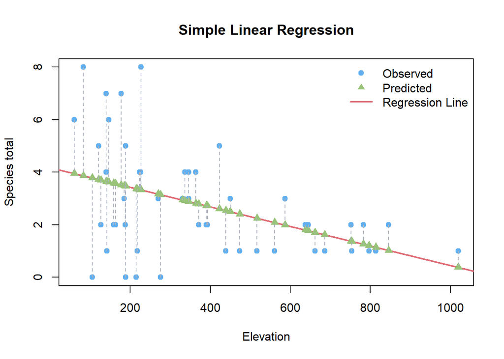

```r
atom_black   <- "#282C34"
atom_blue    <- "#61AFEF"
atom_red     <- "#E06C75"
atom_green   <- "#98C379"
atom_magenta <- "#C678DD"
atom_cyan    <- "#56B6C2"
atom_white   <- "#ABB2BF"

## Plot the data proper.
plot(x, y,
  pch  = 19,
  col  = atom_blue,
  xlab = "Elevation", ylab = "Species total",
  main = "Simple Linear Regression")

## Plot the fitted line on top of the data.
abline(a, b, col=atom_red, lwd=2)

## Add predicted values.
points(x, yhat,
  pch = 17, # Triangle
  col = atom_green,
  cex = 1.2)

## Draw the residual lines on top of the predicted values.
segments(
  x0  = x, y0 = y,
  x1  = x, y1 = yhat,
  lty = 2,
  col = atom_white)

## Add the (John) legend
legend("topright",
  legend = c("Observed", "Predicted", "Regression Line"),
  pch    = c(19, 17, NA),
  lty    = c(NA, NA, 1),
  col    = c(atom_blue, atom_green, atom_red),
  lwd    = c(NA, NA, 2),
  bty    = "n")
```

#### iii. ggplot2

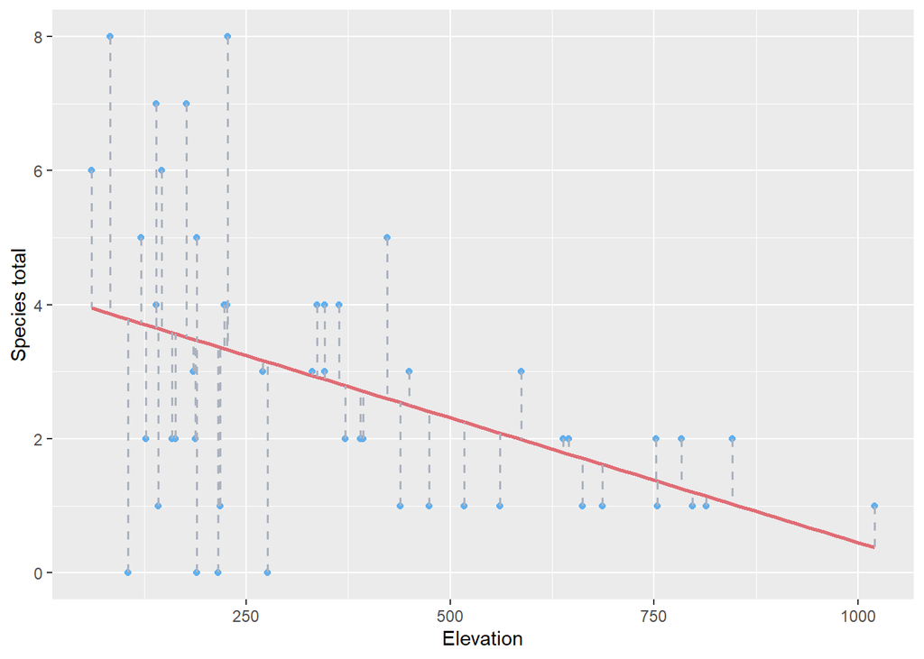

```r
library(ggplot2) ## install.packages("ggplot2")

ggplot2::ggplot(df_xy, aes(Elevation, `Species total`)) +
  ggplot2::geom_point(colour=atom_blue) +
  ggplot2::geom_smooth(method="lm", colour=atom_red, se=FALSE) +
  ggplot2::geom_segment(x=x, y=y, xend=x, yend=yhat,
    colour    = atom_white,
    linetype  = 2,   ## Dashed. See ?linetype.
    linewidth = 0.7) ## In increments of 0.75mm. See ?linewidth.
```

## B. Multiple linear regression

### 1. Read in both annual precipitation and temperature data.

Extract the data following the instructions from A4–5.

```r
sr_prec      <- terra::rast("../data/annual_precipitation.tif")
sv_prec_elev <- terra::extract(sr_prec, sv_coords)
x1           <- sv_prec_elev$annual_precipitation

sr_temp      <- terra::rast("../data/annual_temperature.tif")
sv_temp_elev <- terra::extract(sr_temp, sv_coords)
x2           <- sv_temp_elev$annual_temperature
```

### 2. Combine the extracted data with the species and elevation data into a single dataframe.

```r
df_x1x2y <- data.frame(x1, x2, y)
colnames(df_x1x2y) <- c("Annual precipitation", "Annual temperature", "Species total")
```

### 3. Perform multiple linear regression using the “lm” function.

```r
## Fit the multiple linear regression model.
model <- lm(y ~ x1 + x2)

## Display the model summary.
summary(model)
```

```
##
## Call:
## lm(formula = y ~ x1 + x2)
##
## Residuals:
##     Min      1Q  Median      3Q     Max
## -2.8578 -1.4076 -0.0616  0.9945  6.1924
##
## Coefficients:
##              Estimate Std. Error t value Pr(>|t|)
## (Intercept) 75.404554  26.471603   2.849  0.00655 **
## x1          -0.027903   0.008067  -3.459  0.00118 **
## x2          -0.982391   0.530503  -1.852  0.07048 .
## ---
## Signif. codes:  0 '***' 0.001 '**' 0.01 '*' 0.05 '.' 0.1 ' ' 1
##
## Residual standard error: 1.811 on 46 degrees of freedom
## Multiple R-squared:  0.2855, Adjusted R-squared:  0.2545
## F-statistic: 9.191 on 2 and 46 DF,  p-value: 0.0004382
```

```r
## Display the Regression coefficients.
coef(model)
```

```
## (Intercept)          x1          x2
## 75.40455428 -0.02790293 -0.98239094
```

### 4. Which relationship is statistically significant?

Based on the results above, only x1 (Annual precipitation) is statistically significant as it has a very low p-value of 0.001. This is lower than most alpha (0.1, 0.05, 0.01, 0.005), meaning it is highly significant.

However, x2 (Annual temperature) is not statistically significant as it has a rather high p-value of 0.07. This is higher than most alpha (0.05, 0.01, 0.005) meaning it is not very significant. It would only be statistically significant for alpha=0.1.